# Naive Bayes with Mixed Feature Types — Wisconsin Breast Cancer (WDBC)

Biostatistics 735/794 — Machine Learning in Public Health (R)

Author

Alexander McLain

Published

September 17, 2026

# 1 Setup

We reuse the WDBC data and the train/test split from the previous two examples.

```r
url_data  <- "https://archive.ics.uci.edu/ml/machine-learning-databases/breast-cancer-wisconsin/wdbc.data"
raw <- read.csv(url_data, header = FALSE)

names(raw) <- c("ID","Diagnosis",
                "radius_mean","texture_mean","perimeter_mean","area_mean","smoothness_mean",
                "compactness_mean","concavity_mean","concave_points_mean","symmetry_mean","fractal_dimension_mean",
                "radius_se","texture_se","perimeter_se","area_se","smoothness_se",
                "compactness_se","concavity_se","concave_points_se","symmetry_se","fractal_dimension_se",
                "radius_worst","texture_worst","perimeter_worst","area_worst","smoothness_worst",
                "compactness_worst","concavity_worst","concave_points_worst","symmetry_worst","fractal_dimension_worst")

bc <- raw %>%
  as_tibble() %>%
  mutate(Diagnosis = factor(Diagnosis, levels = c("B","M"))) %>%  # B = negative, M = positive
  select(-ID)

set.seed(42)
split <- initial_split(bc, prop = 0.8, strata = Diagnosis)
train <- training(split)
test  <- testing(split)
```

A helper to compute the metrics we’ve discussed (AUC is threshold-free; others use a threshold, default 0.5):

```r
eval_metrics <- function(truth, prob_pos, thr = 0.5) {
  truth <- factor(truth, levels = c("B","M"))     # "M" is event
  cls   <- factor(ifelse(prob_pos >= thr, "M","B"), levels = c("B","M"))
  tibble(
    AUC  = roc_auc_vec(truth, prob_pos, event_level = "second"),
    Sens = sens_vec(truth, cls,        event_level = "second"),
    Spec = spec_vec(truth, cls,        event_level = "second"),
    PPV  = ppv_vec (truth, cls,        event_level = "second"),
    NPV  = npv_vec (truth, cls,        event_level = "second"),
    Acc  = accuracy_vec(truth, cls)
  )
}
```

# 2 Part A — **Gaussian Naive Bayes** (treat all predictors as continuous)

`e1071::naiveBayes` models numeric predictors with a Gaussian density per class and factors with multinomial/Bernoulli. Here we keep **all 30 features numeric** → Gaussian NB.

```r
nb_gauss <- naiveBayes(Diagnosis ~ ., data = train, laplace = 0)  # no smoothing needed for continuous

p_tr_g <- predict(nb_gauss, newdata = train, type = "raw")[,"M"]
p_te_g <- predict(nb_gauss, newdata = test,  type = "raw")[,"M"]

metrics_gauss <- bind_rows(
  eval_metrics(train$Diagnosis, p_tr_g) %>% mutate(Set = "Train"),
  eval_metrics(test$Diagnosis,  p_te_g) %>% mutate(Set = "Test")
) %>% relocate(Set)

kbl2(metrics_gauss, caption = "Gaussian Naive Bayes: Performance (threshold = 0.5)")
```

Gaussian Naive Bayes: Performance (threshold = 0.5)

| Set | AUC | Sens | Spec | PPV | NPV | Acc |
| --- | --- | --- | --- | --- | --- | --- |
| Train | 0.988 | 0.899 | 0.958 | 0.927 | 0.941 | 0.936 |
| Test | 0.984 | 0.907 | 0.903 | 0.848 | 0.942 | 0.904 |

ROC curve (train vs test):

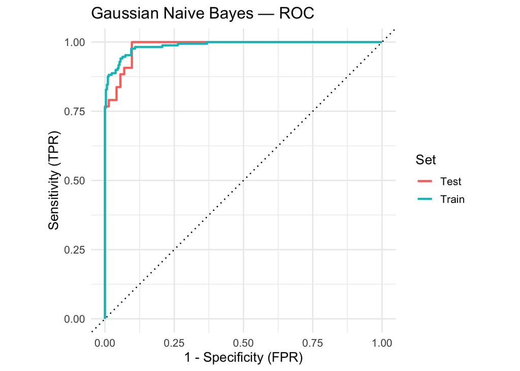

```r
train$estimate <- p_tr_g
test$estimate  <- p_te_g
roc_train_g <- yardstick::roc_curve(data = train, Diagnosis, estimate, event_level = "second") %>% mutate(Set = "Train")
roc_test_g  <- yardstick::roc_curve(data = test, Diagnosis,  estimate, event_level = "second") %>% mutate(Set = "Test")

bind_rows(roc_train_g, roc_test_g) %>%
  ggplot(aes(x = 1 - specificity, y = sensitivity, color = Set)) +
  geom_path(linewidth = 1) + geom_abline(slope = 1, intercept = 0, linetype = 3) +
  coord_equal() + theme_minimal(base_size = 13) +
  labs(title = "Gaussian Naive Bayes — ROC", x = "1 - Specificity (FPR)", y = "Sensitivity (TPR)")
```

# 3 Part B — **Mixed-Type Naive Bayes** (some binary, some multinomial, some continuous)

Here we transform a few predictors to **binary** (median split) and a few to **multinomial** (tertiles), and leave the rest **continuous**. `naiveBayes` will combine the appropriate likelihoods under the Naive assumption.

**Choices for this demo**

- Binary: `radius_mean`, `texture_mean`, `perimeter_mean` (High vs Low, median split)
- Multinomial (3-level): `area_mean`, `smoothness_mean` (Low/Med/High via tertiles)
- Continuous: all remaining features stay numeric

```r
make_mixed <- function(df) {
  out <- df

  # Binary via median split
  for (v in c("radius_mean","texture_mean","perimeter_mean")) {
    med <- median(out[[v]], na.rm = TRUE)
    out[[paste0(v,"_bin")]] <- factor(ifelse(out[[v]] > med, "High","Low"))
    out[[v]] <- NULL
  }

  # Multinomial via tertiles
  for (v in c("area_mean","smoothness_mean")) {
    qs <- quantile(out[[v]], probs = c(1/3, 2/3), na.rm = TRUE)
    cutv <- cut(out[[v]],
                breaks = c(-Inf, qs[1], qs[2], Inf),
                labels = c("Low","Med","High"),
                right = TRUE)
    out[[paste0(v,"_ter")]] <- factor(cutv)
    out[[v]] <- NULL
  }

  out
}

train_mx <- make_mixed(train)
test_mx  <- make_mixed(test)
```

Fit Naive Bayes with **Laplace smoothing** (recommended when categorical levels can be rare):

```r
nb_mixed <- naiveBayes(Diagnosis ~ ., data = train_mx, laplace = 1)

p_tr_mx <- predict(nb_mixed, newdata = train_mx, type = "raw")[,"M"]
p_te_mx <- predict(nb_mixed, newdata = test_mx,  type = "raw")[,"M"]

metrics_mixed <- bind_rows(
  eval_metrics(train_mx$Diagnosis, p_tr_mx) %>% mutate(Set = "Train"),
  eval_metrics(test_mx$Diagnosis,  p_te_mx) %>% mutate(Set = "Test")
) %>% relocate(Set)

kbl2(metrics_mixed, caption = "Mixed-Type Naive Bayes (binary + multinomial + continuous): Performance (threshold = 0.5)")
```

Mixed-Type Naive Bayes (binary + multinomial + continuous): Performance (threshold = 0.5)

| Set | AUC | Sens | Spec | PPV | NPV | Acc |
| --- | --- | --- | --- | --- | --- | --- |
| Train | 0.987 | 0.899 | 0.958 | 0.927 | 0.941 | 0.936 |
| Test | 0.987 | 0.907 | 0.903 | 0.848 | 0.942 | 0.904 |

ROC curve (train vs test) for the mixed model:

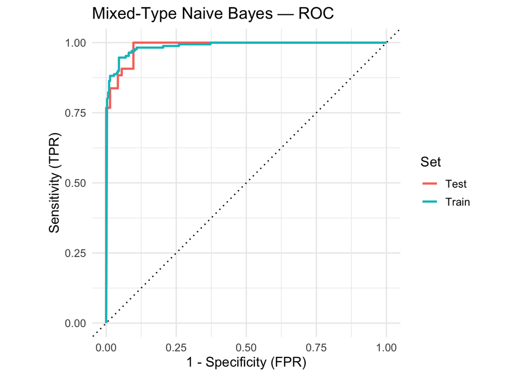

```r
train$estimate_mx <- p_tr_mx
test$estimate_mx  <- p_te_mx
roc_train_m <- yardstick::roc_curve(data = train, Diagnosis, estimate_mx, event_level = "second") %>% mutate(Set = "Train")
roc_test_m  <- yardstick::roc_curve(data = test, Diagnosis,  estimate_mx, event_level = "second") %>% mutate(Set = "Test")

bind_rows(roc_train_m, roc_test_m) %>%
  ggplot(aes(x = 1 - specificity, y = sensitivity, color = Set)) +
  geom_path(linewidth = 1) + geom_abline(slope = 1, intercept = 0, linetype = 3) +
  coord_equal() + theme_minimal(base_size = 13) +
  labs(title = "Mixed-Type Naive Bayes — ROC", x = "1 - Specificity (FPR)", y = "Sensitivity (TPR)")
```

## 3.1 Summary So Far

- **Naive Bayes is a framework**: multiply class-conditional likelihoods per feature under conditional independence.
- With `e1071::naiveBayes`, **numeric** variables are modeled as **Gaussian**; **factors** are modeled as **multinomial/Bernoulli** with optional **Laplace smoothing**.
- You can **mix feature types** in the same model (as we did with binary + multinomial + continuous).
- Report both **threshold-free (AUC)** and **thresholded (Se/Sp/PPV/NPV/Acc)** performance.

# 4 Part C — **Kernel-Density Naive Bayes** (non-parametric for continuous features)

Not all of the variables have a normal distribution. For example:

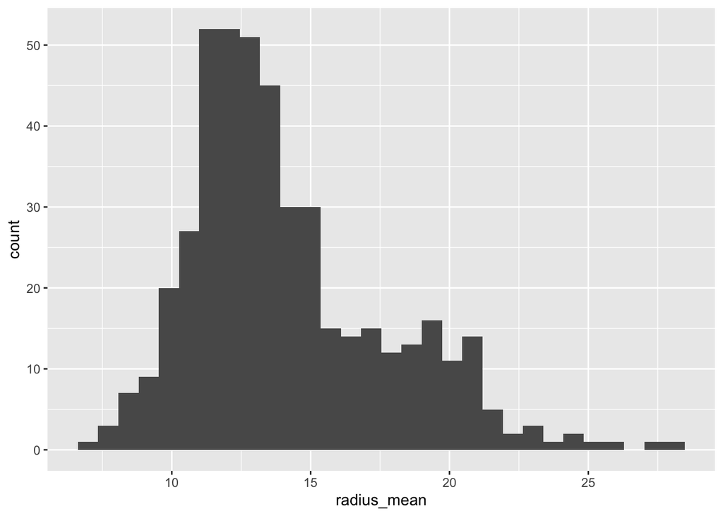

```r
ggplot(data = train) + geom_histogram(aes(radius_mean))
```

We now replace the Gaussian assumption with a **kernel density estimate (KDE)** per class, for every continuous feature. This lets us capture skewness, heavy tails, and multi-modality that a Normal model can’t. `klaR::NaiveBayes()` fits exactly this model with `usekernel = TRUE`: a per-class KDE for every numeric predictor, combined under the same Naive independence assumption as Parts A and B.

```r
nb_kde <- NaiveBayes(Diagnosis ~ ., data = train, usekernel = TRUE)

p_tr_kde <- predict(nb_kde, newdata = train)$posterior[, "M"]
p_te_kde <- predict(nb_kde, newdata = test)$posterior[, "M"]

metrics_kde <- bind_rows(
  eval_metrics(train$Diagnosis, p_tr_kde) %>% mutate(Set = "Train"),
  eval_metrics(test$Diagnosis,  p_te_kde) %>% mutate(Set = "Test")
) %>% relocate(Set)

kbl2(metrics_kde, caption = "Kernel-Density Naive Bayes: Performance (threshold = 0.5)")
```

Kernel-Density Naive Bayes: Performance (threshold = 0.5)

| Set | AUC | Sens | Spec | PPV | NPV | Acc |
| --- | --- | --- | --- | --- | --- | --- |
| Train | 0.992 | 0.929 | 0.996 | 0.994 | 0.959 | 0.971 |
| Test | 0.980 | 0.884 | 0.958 | 0.927 | 0.932 | 0.930 |

ROC curves for KDE-NB:

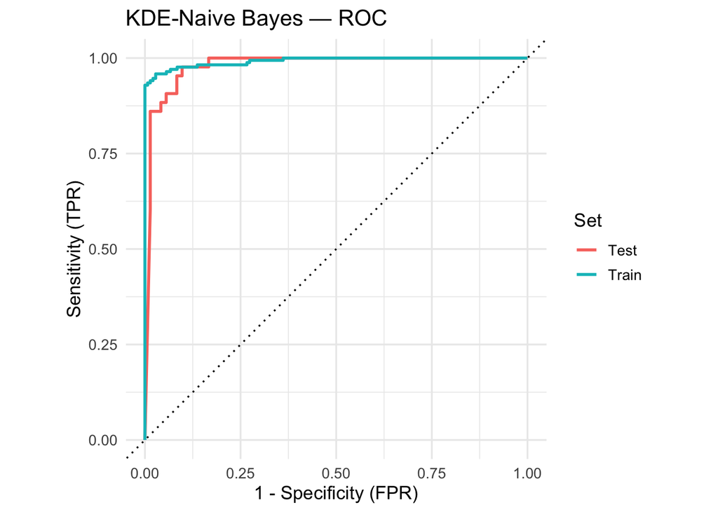

```r
train$estimate_kde <- p_tr_kde
test$estimate_kde  <- p_te_kde
roc_train_kde <- yardstick::roc_curve(data = train, Diagnosis, estimate_kde, event_level = "second") %>% mutate(Set = "Train")
roc_test_kde  <- yardstick::roc_curve(data = test, Diagnosis,  estimate_kde, event_level = "second") %>% mutate(Set = "Test")

bind_rows(roc_train_kde, roc_test_kde) %>%
  ggplot(aes(x = 1 - specificity, y = sensitivity, color = Set)) +
  geom_path(linewidth = 1) + geom_abline(slope = 1, intercept = 0, linetype = 3) +
  coord_equal() + theme_minimal(base_size = 13) +
  labs(title = "KDE-Naive Bayes — ROC", x = "1 - Specificity (FPR)", y = "Sensitivity (TPR)")
```

The bandwidth (`bw`) and kernel (`kernel`) arguments to `NaiveBayes()` control how smooth each class-conditional density is — the KDE analogue of a tuning parameter, worth adjusting if a density looks too wiggly or too flat.

## 4.1 Compare Gaussian NB vs Mixed NB vs KDE-NB (test set)

```r
compare_tbl <- list(
  `Gaussian NB` = eval_metrics(test$Diagnosis,     p_te_g),
  `Mixed NB`    = eval_metrics(test_mx$Diagnosis,  p_te_mx),
  `KDE-NB`      = eval_metrics(test$Diagnosis,     p_te_kde)
) %>%
  imap_dfr(~ mutate(.x, Model = .y)) %>%
  relocate(Model)

kbl2(compare_tbl, caption = "Test-set comparison: Gaussian NB vs Mixed NB vs KDE-NB (threshold = 0.5)")
```

Test-set comparison: Gaussian NB vs Mixed NB vs KDE-NB (threshold = 0.5)

| Model | AUC | Sens | Spec | PPV | NPV | Acc |
| --- | --- | --- | --- | --- | --- | --- |
| Gaussian NB | 0.984 | 0.907 | 0.903 | 0.848 | 0.942 | 0.904 |
| Mixed NB | 0.987 | 0.907 | 0.903 | 0.848 | 0.942 | 0.904 |
| KDE-NB | 0.980 | 0.884 | 0.958 | 0.927 | 0.932 | 0.930 |

**Notes**

- KDE-NB **drops the Normality assumption** for continuous features; it can adapt to skewed or multi-modal FNA features.
- Trade-offs: KDE adds flexibility but may overfit with tiny class-specific samples; the bandwidth acts like a **smoothness** tuning parameter, much like `s()` did for GAMs.